# Pratical learning machine project

Giovanna Ruscitti

Sunday, September 27, 2015

## Introduction

The objective of the present work is to predict the manner in which exercises are done. The model will be created using a training dataset containing data from six people that were asked to perform the exercises in 5 different ways. The “classe” variable of the training set defines the manner in which the exercises were done. A decision tree will be created to predict the “classe” using data from accelerometers on the belt, forearm, arm, and dumbell. A cross-validation will be used to evaluate the model.

## Data cleaning

The training dataset is composed of 160 variables and 19622 records.

```r
dim(allTraining)
```

```
## [1] 19622   160
```

After an overview to the training dataset I have noted that there are some records with DIV!0 values and that such values correspond to the “yes” value of “new_window” variable.

```r
table(allTraining$new_window)
```

```
##
##    no   yes
## 19216   406
```

Since there are only 406 “yes” values for “new_window” variable, I decided to filter such records.

```r
allTrainingFilt <- subset(allTraining,allTraining$new_window =="no")
```

## Variables

In order to make the training dataset as simple as possible I have deleted all variables having only one different value, since they don’t give any further information.

```r
toKeep <- function(v){if (length(unique(v))<=1) 0 else 1}
valToKeep <- c(1:160)*sapply(allTrainingFilt[,],toKeep)
valToKeep <- valToKeep[valToKeep!=0]
myTraining <-allTrainingFilt[valToKeep]
```

I have also dropped all the variables not related to accelerometers:

- X
- user_name
- raw_timestamp_part_1
- raw_timestamp_part_2
- cvtd_timestamp
- new_window
- num_window

## Preliminary models

In order to choose the method to be used, I have created two different models, one using *rpart* method and the other using *random forest* method with 50 trees. Since better results were obtained in terms of accuracy with *random forest* method (accuracy = **99%**) with respect to *rpart* method (accuracy = **51%**), I decided to go on with random forest method.

```r
#modFit.rpart <- train(classe~., data=myTraining, method="rpart")
```

```
## CART
##
## 19216 samples
##    52 predictor
##     5 classes: 'A', 'B', 'C', 'D', 'E'
##
## No pre-processing
## Resampling: Bootstrapped (25 reps)
## Summary of sample sizes: 19216, 19216, 19216, 19216, 19216, 19216, ...
## Resampling results across tuning parameters:
##
##   cp          Accuracy   Kappa       Accuracy SD  Kappa SD
##   0.03572208  0.5124576  0.36740574  0.02116481   0.03484043
##   0.06004608  0.4138041  0.20237167  0.06361388   0.10647632
##   0.11465988  0.3215876  0.05370494  0.03949192   0.06185806
##
## Accuracy was used to select the optimal model using  the largest value.
## The final value used for the model was cp = 0.03572208.
```

```r
#modFit.rf <- train(classe~., data=myTraining, method="rf", do.trace=TRUE, ntree=50)
```

```
## Random Forest
##
## 19216 samples
##    52 predictor
##     5 classes: 'A', 'B', 'C', 'D', 'E'
##
## No pre-processing
## Resampling: Bootstrapped (25 reps)
## Summary of sample sizes: 19216, 19216, 19216, 19216, 19216, 19216, ...
## Resampling results across tuning parameters:
##
##   mtry  Accuracy   Kappa      Accuracy SD  Kappa SD
##    2    0.9914515  0.9891838  0.001600487  0.002021207
##   27    0.9915068  0.9892542  0.001656440  0.002090704
##   52    0.9817915  0.9769590  0.004664746  0.005903181
##
## Accuracy was used to select the optimal model using  the largest value.
## The final value used for the model was mtry = 27.
```

## Final model

A model has been created with *random forest* method and the validation of the model has been done using the *cross-validation* methodology. Even if cross-validation will been used, I have decided to split data into training and test in other to have some data to perform a further model behavior evaluation.

```r
set.seed(124)
inTrain<-createDataPartition(y=myTraining$classe,p=0.75,list=FALSE)
training<-myTraining[inTrain,]
testing<-myTraining[-inTrain,]
```

A random forest model will be created with 200 trees and a 5-fold cross-validation will be used to validate the model.

```r
#tc<-trainControl(method="cv",number=5)
#modFit.rf.final <- train(classe~., data=training, method="rf", ntree=200,trControl=tc, importance=TRUE)
```

As shown below the accuracy is **99.1%**.

```r
modFit.rf.final
```

```
## Random Forest
##
## 14414 samples
##    52 predictor
##     5 classes: 'A', 'B', 'C', 'D', 'E'
##
## No pre-processing
## Resampling: Cross-Validated (5 fold)
## Summary of sample sizes: 11530, 11531, 11532, 11532, 11531
## Resampling results across tuning parameters:
##
##   mtry  Accuracy   Kappa      Accuracy SD  Kappa SD
##    2    0.9900793  0.9874487  0.002089024  0.002643198
##   27    0.9907732  0.9883267  0.002159104  0.002731187
##   52    0.9829337  0.9784078  0.003824601  0.004840447
##
## Accuracy was used to select the optimal model using  the largest value.
## The final value used for the model was mtry = 27.
```

## Error evaluation

In the picture below it is possible to see the out of bag (OOB) error behaviour depends on the number of trees.

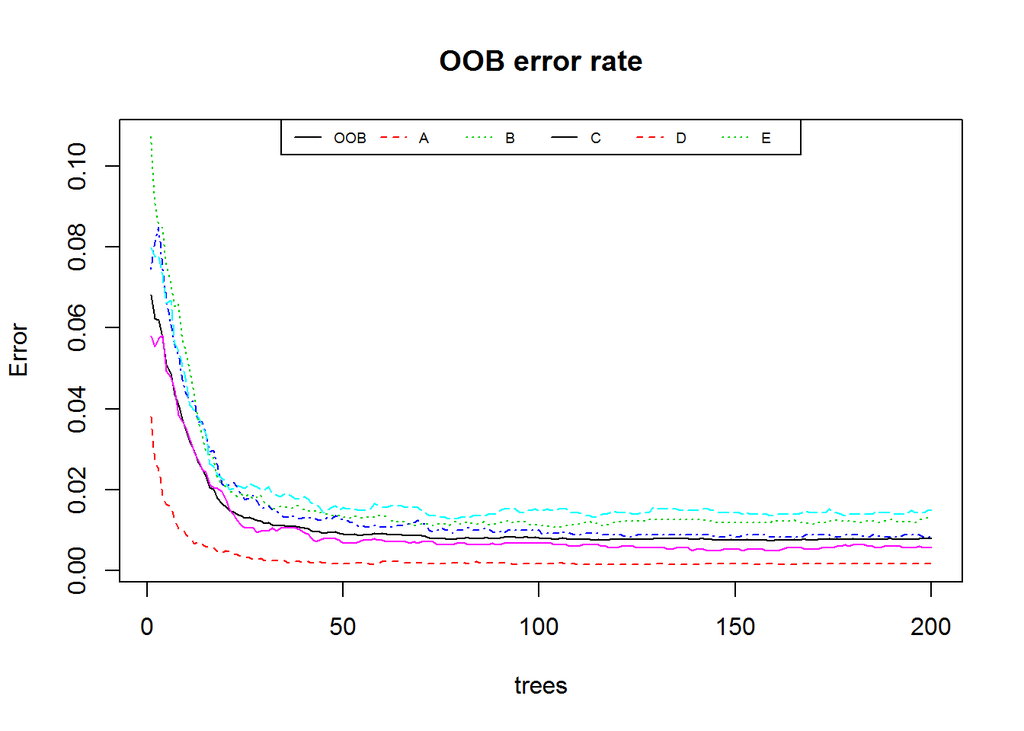

When the number is greater than 50 the error rate tends to be constant. Since the computational time is not so high I decided to keep 200 trees in my final model. Using the model to predict the training set it is possible to see that the in-sample error is zero.

```r
pred<-predict(modFit.rf.final$finalModel,newdata=training)
confusionMatrix(data=pred,reference=training$classe)
```

```
## Confusion Matrix and Statistics
##
##           Reference
## Prediction    A    B    C    D    E
##          A 4104    0    0    0    0
##          B    0 2789    0    0    0
##          C    0    0 2514    0    0
##          D    0    0    0 2361    0
##          E    0    0    0    0 2646
##
## Overall Statistics
##
##                Accuracy : 1
##                  95% CI : (0.9997, 1)
##     No Information Rate : 0.2847
##     P-Value [Acc > NIR] : < 2.2e-16
##
##                   Kappa : 1
##  Mcnemar's Test P-Value : NA
##
## Statistics by Class:
##
##                      Class: A Class: B Class: C Class: D Class: E
## Sensitivity            1.0000   1.0000   1.0000   1.0000   1.0000
## Specificity            1.0000   1.0000   1.0000   1.0000   1.0000
## Pos Pred Value         1.0000   1.0000   1.0000   1.0000   1.0000
## Neg Pred Value         1.0000   1.0000   1.0000   1.0000   1.0000
## Prevalence             0.2847   0.1935   0.1744   0.1638   0.1836
## Detection Rate         0.2847   0.1935   0.1744   0.1638   0.1836
## Detection Prevalence   0.2847   0.1935   0.1744   0.1638   0.1836
## Balanced Accuracy      1.0000   1.0000   1.0000   1.0000   1.0000
```

The out of sample error is **0.79%** (see OOB estimate of error rate below) and, as expected, it greater than the in-sample error.

```r
modFit.rf.final$finalModel
```

```
##
## Call:
##  randomForest(x = x, y = y, ntree = 200, mtry = param$mtry, importance = TRUE,      do.trace = TRUE)
##                Type of random forest: classification
##                      Number of trees: 200
## No. of variables tried at each split: 27
##
##         OOB estimate of  error rate: 0.79%
## Confusion matrix:
##      A    B    C    D    E class.error
## A 4097    6    0    0    1 0.001705653
## B   24 2753   10    2    0 0.012907852
## C    0   12 2493    9    0 0.008353222
## D    1    2   30 2326    2 0.014824227
## E    0    2    6    7 2631 0.005668934
```

As a further error evaluation I have generated the confusion matrix

```r
pred<-predict(modFit.rf.final,newdata=testing)
confusionMatrix(data=pred,reference=testing$classe)
```

```
## Confusion Matrix and Statistics
##
##           Reference
## Prediction    A    B    C    D    E
##          A 1366    7    0    0    0
##          B    1  919    4    1    0
##          C    0    3  828    8    1
##          D    0    0    6  777    3
##          E    0    0    0    0  878
##
## Overall Statistics
##
##                Accuracy : 0.9929
##                  95% CI : (0.9901, 0.9951)
##     No Information Rate : 0.2847
##     P-Value [Acc > NIR] : < 2.2e-16
##
##                   Kappa : 0.991
##  Mcnemar's Test P-Value : NA
##
## Statistics by Class:
##
##                      Class: A Class: B Class: C Class: D Class: E
## Sensitivity            0.9993   0.9892   0.9881   0.9885   0.9955
## Specificity            0.9980   0.9985   0.9970   0.9978   1.0000
## Pos Pred Value         0.9949   0.9935   0.9857   0.9885   1.0000
## Neg Pred Value         0.9997   0.9974   0.9975   0.9978   0.9990
## Prevalence             0.2847   0.1935   0.1745   0.1637   0.1837
## Detection Rate         0.2845   0.1914   0.1724   0.1618   0.1828
## Detection Prevalence   0.2859   0.1926   0.1749   0.1637   0.1828
## Balanced Accuracy      0.9986   0.9938   0.9925   0.9932   0.9977
```

and the error rate for the testing dataset.

```r
errRate = function(values,prediction){100*sum(values!=pred)/length(values)}
errRate(testing$classe,pred)
```

```
## [1] 0.7080383
```

I have obtained an error rate of **0.71%**, that is very close to the OOB estimate obtained above.